# Growth

Cullen Molitor, Felicia Cruz, Peter Menzies

2022-05-14

Consider the following model of forest growth (where forest size in measured in units of carbon ($C$))

- $dC/dt = r*C$ for forests where C is below a threshold canopy closure
- $dC/dt = g*(1- C/K)$ for forests where carbon is at or above the threshold canopy closure
- $K$ is a carrying capacity in units of carbon

The size of the forest ($C$), Canopy closure threshold and carrying capacity are all in units of kg carbon

You could think of the canopy closure threshold as the size of the forest at which growth rates change from exponential to linear

You can think of $r$, as early exponential growth rate and $g$ as the linear growth rate once canopy closure has been reached

**1. Implement this model in R (as a differential equation)**

Grading 25% - we will look for:

- correct implementation
- good programming style
- meaningful variable names
- comments/documentation throughout

```r
source(here("R", "forest_growth.R"))
forest_growth
```

```
## function (time, forest_size, params)
## {
##     dC_dt <- case_when(forest_size < params$canopy_closure_threshold ~
##         params$exp_growth_rate * forest_size, T ~ params$lin_growth_rate *
##         (1 - (forest_size/params$carrying_capacity)))
##     return(list(dC_dt))
## }
```

**2. Run the model for 300 years (using the ODE solver) starting with an initial forest size of 10 kgC, and using the following parameters**

- canopy closure threshold of 50 kgC
- K = 250 kgC (carrying capacity)
- r = 0.01 (exponential growth rate before before canopy closure)
- g = 2 kg/year (linear growth rate after canopy closure)
- Graph the results. (15% - we look for an appropriate graphs and good visualization practice - labels, etc)

```r
time = seq(from = 1, to = 300, by = 1)
forest_size = 10

parameters = list(
  canopy_closure_threshold = 50,
  carrying_capacity = 250,
  exp_growth_rate = 0.01,
  lin_growth_rate = 2)

results = ode(
  y = forest_size,
  times = time,
  func = forest_growth,
  parms = parameters) %>%
  as.data.frame %>%
  rename(year = time, forest_size = `1`)
```

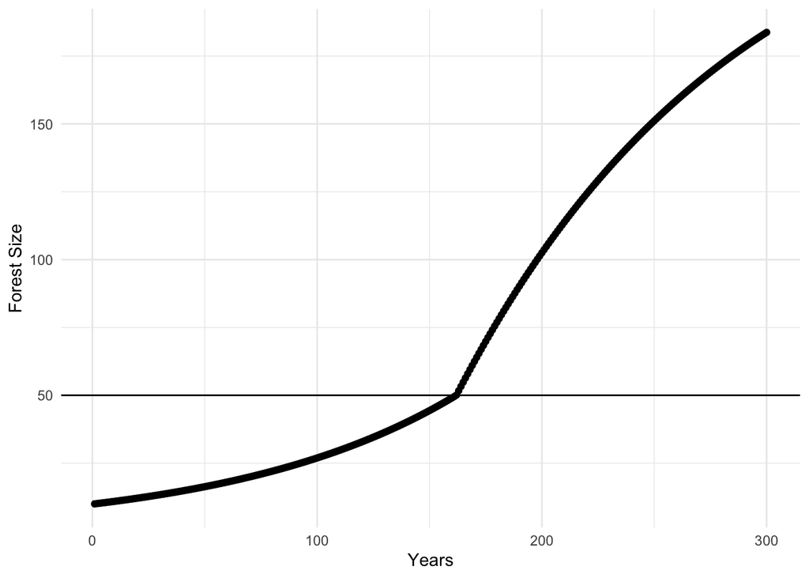

```r
ggplot(results, aes(year, forest_size)) +
  geom_point() +
  geom_hline(yintercept = parameters$canopy_closure_threshold) +
  labs(y = "Forest Size", x = "Years") +
  theme_minimal()
```

**3. Run a Sobol sensitivity analysis that explores how the estimated maximum and mean forest size (e.g maximum and mean values of C over the 300 years) varies with the pre canopy closure growth rate (r) and post-canopy closure growth rate (g) and canopy closure threshold and carrying capacity(K)**

- Assume that parameters are all normally distributed with means as given above and standard deviation of 10% of mean value
- Graph the results of the sensitivity analysis as a box plot of maximum forest size and a plot of the two Sobol indices (S and T). (25% - correct implementation of Sobol and graph We also look for good graphing style -labels etc)

```r
# Create function to compute max forest_size and mean forest_size form ode results
compute_metrics <- function(results) {

  max_forest_size = max(results$forest_size)
  mean_forest_size = mean(results$forest_size)

  return(list(max_forest_size = max_forest_size, mean_forest_size = mean_forest_size))
}
```

```r
# Create wrapper function for use with pmap() to vary all parameters
p_wrapper = function(canopy_closure_threshold, carrying_capacity, exp_growth_rate,
                     lin_growth_rate, forest_size, time, func) {

  parameters = list(canopy_closure_threshold = canopy_closure_threshold,
                    carrying_capacity = carrying_capacity,
                    exp_growth_rate = exp_growth_rate,
                    lin_growth_rate = lin_growth_rate)

  results = ode(y = forest_size, times = time, func = func, parms = parameters, method = "daspk")
  colnames(results) = c("time", "forest_size")

  # get max and mean forest_size
  metrics = compute_metrics(as.data.frame(results))
  return(metrics)
}
```

```r
# Generate normally distributed parameter sets and bind into dataframe
n_params <- 100
canopy_closure_threshold <- rnorm(mean = 50, sd = 5, n = n_params)
carrying_capacity <- rnorm(mean = 250, sd = 25, n = n_params)
exp_growth_rate <- rnorm(mean = 0.01, sd = 0.001, n = n_params)
lin_growth_rate <- rnorm(mean = 2, sd = 0.2, n = n_params)
X1 = cbind.data.frame(canopy_closure_threshold, carrying_capacity = carrying_capacity,
                      exp_growth_rate = exp_growth_rate, lin_growth_rate = lin_growth_rate)

# Repeat to get second set of samples
canopy_closure_threshold <- rnorm(mean = 50, sd = 5, n = n_params)
carrying_capacity <- rnorm(mean = 250, sd = 25, n = n_params)
exp_growth_rate <- rnorm(mean = 0.01, sd = 0.001, n = n_params)
lin_growth_rate <- rnorm(mean = 2, sd = 0.2, n = n_params)
X2 = cbind.data.frame(canopy_closure_threshold, carrying_capacity = carrying_capacity,
                      exp_growth_rate = exp_growth_rate, lin_growth_rate = lin_growth_rate)

sobol_salt <- sobolSalt(model = NULL, X1, X2, nboot = 300)
colnames(sobol_salt$X) <- c("canopy_closure_threshold","carrying_capacity",
                           "exp_growth_rate", "lin_growth_rate")

# Take a look at our parameter sets
head(sobol_salt$X)
```

```
##      canopy_closure_threshold carrying_capacity exp_growth_rate lin_growth_rate
## [1,]                 44.85229          240.4691     0.008780778        2.468344
## [2,]                 45.44282          247.6385     0.009303122        1.796722
## [3,]                 58.38348          299.0834     0.009178016        2.157362
## [4,]                 48.08004          247.2497     0.010277138        2.015035
## [5,]                 48.33596          264.9804     0.009942649        1.931012
## [6,]                 45.41581          277.0472     0.011254541        2.305334
```

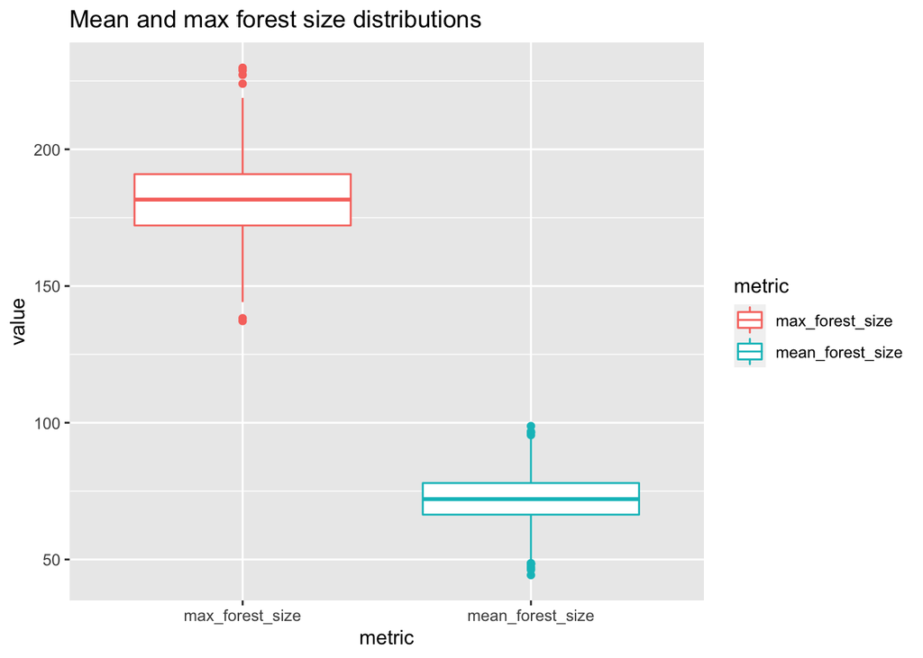

```r
sobol_params_df <- as.data.frame(sobol_salt$X)
sobol_results <- sobol_params_df %>%
  pmap(p_wrapper, time = time, forest_size = forest_size, func = forest_growth)

sobol_results_df <- sobol_results %>%
  map_dfr(`[`,c("max_forest_size","mean_forest_size"))

sobol_results_longer <- sobol_results_df %>%
  pivot_longer(cols = c(max_forest_size, mean_forest_size),
               names_to = "metric")

ggplot(sobol_results_longer, aes(metric, value, col = metric)) +
  geom_boxplot() +
  labs(title = "Mean and max forest size distributions")
```

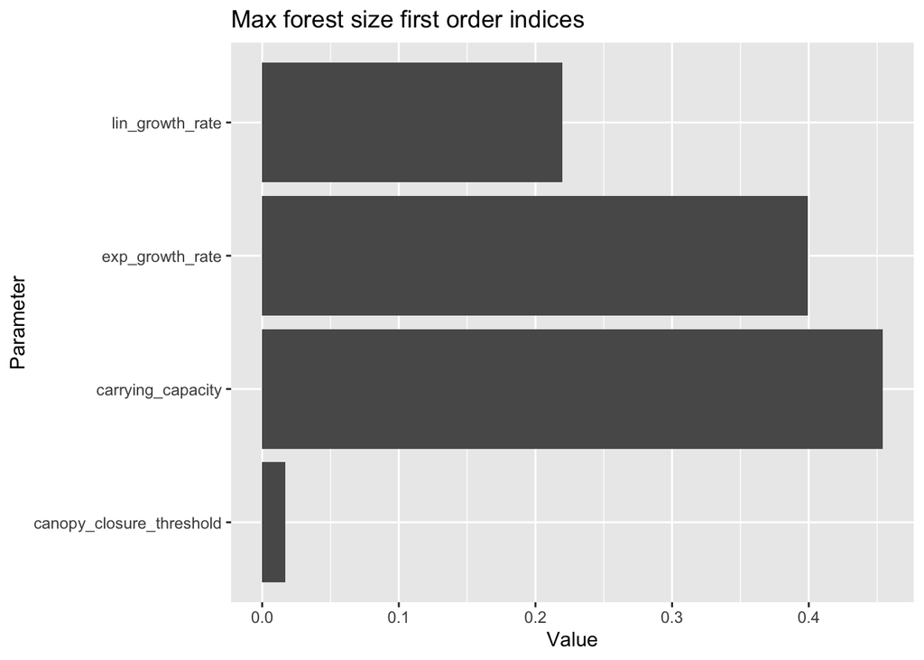

```r
# Sobol indices for max_forest_size
sobol_max_forest_size = sensitivity::tell(sobol_salt, sobol_results_df$max_forest_size)

# first-order indices (main effect without co-variance)
max_forest_size_S <- sobol_max_forest_size$S %>%
  rownames_to_column() %>%
  rename(parameter = rowname) %>%
  mutate(parameter = case_when(
    parameter == "X1" ~ "canopy_closure_threshold",
    parameter == "X2" ~ "carrying_capacity",
    parameter == "X3" ~ "exp_growth_rate",
    parameter == "X4" ~ "lin_growth_rate"))

# total sensitivity indices
max_forest_size_T <- sobol_max_forest_size$T %>%
  rownames_to_column() %>%
  rename(parameter = rowname) %>%
  mutate(parameter = case_when(
    parameter == "X1" ~ "canopy_closure_threshold",
    parameter == "X2" ~ "carrying_capacity",
    parameter == "X3" ~ "exp_growth_rate",
    parameter == "X4" ~ "lin_growth_rate"))

ggplot(max_forest_size_S, aes(x = original, y = parameter)) +
  geom_col() +
  labs(title = "Max forest size first order indices",
       x = "Value",
       y = "Parameter")
```

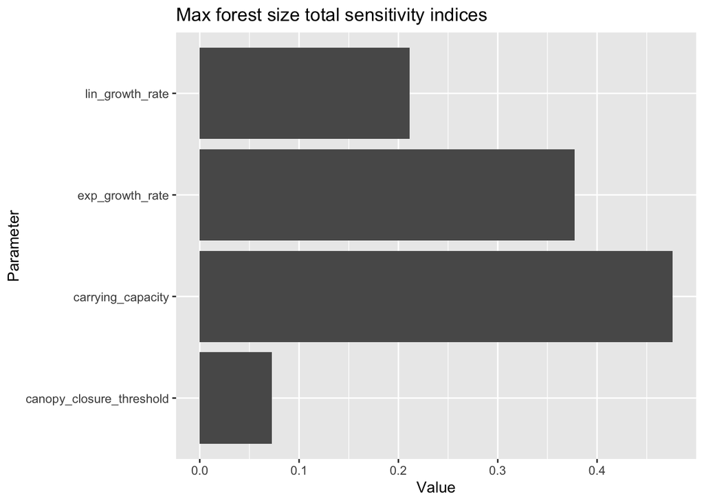

```r
ggplot(max_forest_size_T, aes(x = original, y = parameter)) +
  geom_col() +
  labs(title = "Max forest size total sensitivity indices",
       x = "Value",
       y = "Parameter")
```

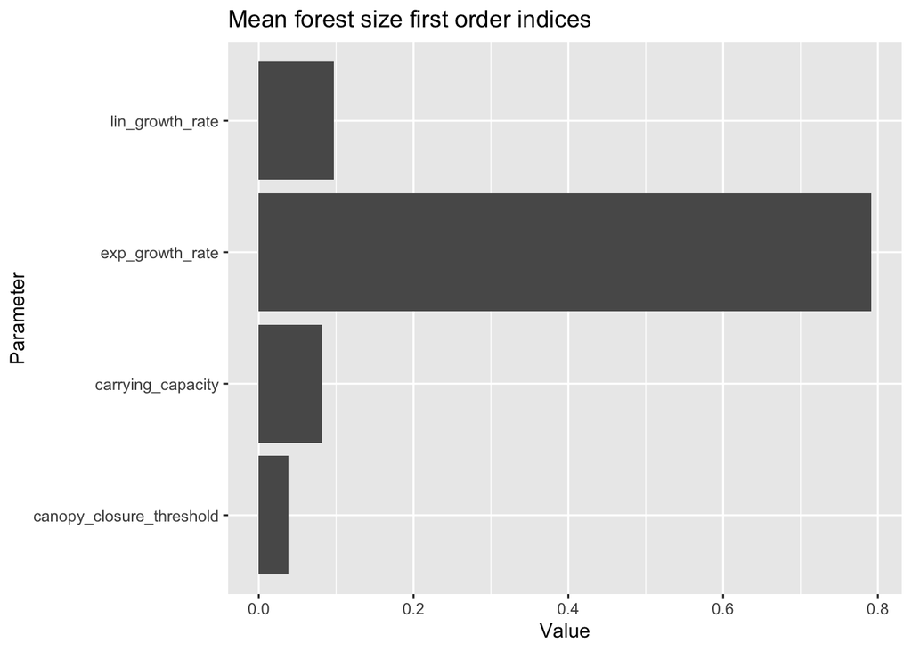

```r
# Sobol indices for mean_forest_size

sobol_mean_forest_size = sensitivity::tell(sobol_salt, sobol_results_df$mean_forest_size)

# first-order indices (main effect without co-variance)
mean_forest_size_S <- sobol_mean_forest_size$S %>%
  rownames_to_column() %>%
  rename(parameter = rowname) %>%
  mutate(parameter = case_when(
    parameter == "X1" ~ "canopy_closure_threshold",
    parameter == "X2" ~ "carrying_capacity",
    parameter == "X3" ~ "exp_growth_rate",
    parameter == "X4" ~ "lin_growth_rate"))

# total sensitivity indices
mean_forest_size_T <- sobol_mean_forest_size$T %>%
  rownames_to_column() %>%
  rename(parameter = rowname) %>%
  mutate(parameter = case_when(
    parameter == "X1" ~ "canopy_closure_threshold",
    parameter == "X2" ~ "carrying_capacity",
    parameter == "X3" ~ "exp_growth_rate",
    parameter == "X4" ~ "lin_growth_rate"))

ggplot(mean_forest_size_S, aes(x = original, y = parameter)) +
  geom_col() +
  labs(title = "Mean forest size first order indices",
       x = "Value",
       y = "Parameter")
```

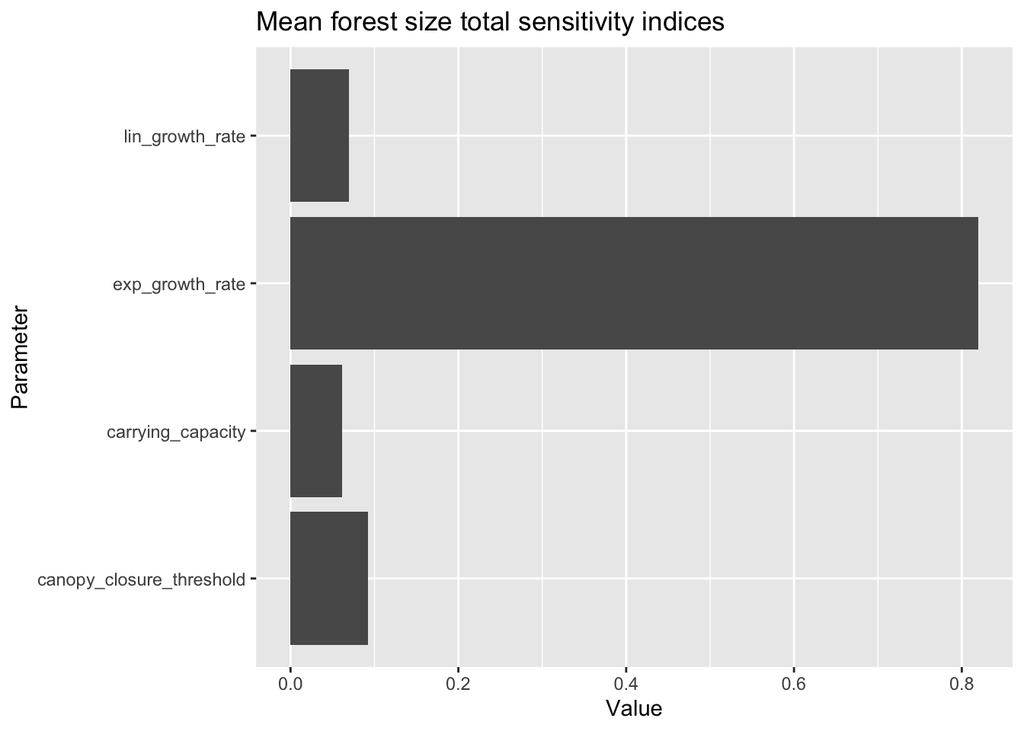

```r
ggplot(mean_forest_size_T, aes(x = original, y = parameter)) +
  geom_col() +
  labs(title = "Mean forest size total sensitivity indices",
       x = "Value",
       y = "Parameter")
```

In 2-3 sentences, discuss what the results of your simulation might mean for climate change impacts on forest growth (e.g think about what parameters climate change might influence ). (25% - we look for reasonable discussion that uses the results from your analysis and give extra points for discussions that offer particularly creative or insightful commentary)

Submit R markdown with model implementation, graphs and sensitivity analysis and R file with your model (Final 10% for well-organized, clearly documented R markdown)

**From our analysis we determined that for `max_forest_size`, carrying capacity was the parameter most sensitive to uncertainty—and for `mean_forest_size`, exponential growth rate was the parameter most sensitive to uncertainty. Carrying capacity, which is often limited by water supply, will likely be impacted due to less precipitation and more frequent droughts caused by climate change. Additionally, weather events such as wildfires and heat waves will be further amplified by climate change which can also affect forest size. All of these factors can also change the growth rates (less precipitation and higher temperatures can lead to forests growing more slowly).**